# Benchmarking CMEnt on Simulated ONT Data

CMEnt vs DMRcate vs dmrseq vs hummingbird

CMEnt Package

2026-06-08

# Contents

## 1 Introduction

Methods:

- **CMEnt** seed-guided, correlation-based DMR assembly
- **DMRcate** Gaussian Kernel smoothing-based DMR detection
- **dmrseq** BSseq-native region-level inference
- **hummingbird** HMM-based DMR detection

Data:

Primary goal:

- assess CMEnt performance against ground truth
- compare with DMRcate, dmrseq, and hummingbird using the same dataset

## 2 Setup and Dependencies

```r
try(devtools::load_all(), silent = TRUE)
suppressPackageStartupMessages({
    try(library(CMEnt), silent = TRUE)
    library(bsseq)
    library(data.table)
    library(ggplot2)
    library(dplyr)
    library(GenomicRanges)
    library(SummarizedExperiment)
    library(S4Vectors)
})

getBenchmarkFile <- function(filename) {
    benchmark_file <- ""
    folder <- "simulated_ont"
    if (getwd() == "notebooks") {
        benchmark_file <- file.path("cached_results", folder, filename)
    } else if ("NAMESPACE" %in% dir()) {
        benchmark_file <- file.path("notebooks", "cached_results", folder, filename)
    } else {
        benchmark_file <- file.path("cached_results", folder, filename)
    }
    dir.create(dirname(benchmark_file), showWarnings = FALSE, recursive = TRUE)
    benchmark_file
}

min_seeds <- 2L
min_sites <- 50L
max_pval <- 0.05
testing_mode  <- "parametric"
ext_site_delta_beta  <- 0.1
max_bridge_seeds_gaps <- 1L
max_bridge_extension_gaps <- 2L
max_lookup_dist <- 1000L
method_cache_tag <- sprintf(
    "sites%d_p%s_ext%s_lookup%d",
    min_sites,
    gsub("[^0-9]+", "", sprintf("%.3f", max_pval)),
    gsub("[^0-9]+", "", sprintf("%.3f", ext_site_delta_beta)),
    max_lookup_dist
)
```

### 2.1 Install External Dependencies

```r
if (!requireNamespace("BiocManager", quietly = TRUE)) {
    install.packages("BiocManager")
}

if (!requireNamespace("DMRcate", quietly = TRUE)) {
    BiocManager::install("DMRcate", update = FALSE, ask = FALSE)
}

if (!requireNamespace("dmrseq", quietly = TRUE)) {
    BiocManager::install("dmrseq", update = FALSE, ask = FALSE)
}

if (!requireNamespace("hummingbird", quietly = TRUE)) {
    BiocManager::install("hummingbird", update = FALSE, ask = FALSE)
}

if (!requireNamespace("tidyr", quietly = TRUE)) {
    install.packages("tidyr")
}
```

## 3 Load Simulated Data and Ground Truth

```r
cment_file <- getBenchmarkFile(sprintf("dmrs.CMEnt.%s.rds", method_cache_tag))
dmrcate_file <- getBenchmarkFile(sprintf("dmrs.DMRcate.%s.rds", method_cache_tag))
dmrseq_file <- getBenchmarkFile(sprintf("dmrs.dmrseq.%s.rds", method_cache_tag))
hummingbird_file <- getBenchmarkFile(sprintf("dmrs.hummingbird.%s.rds", method_cache_tag))
pheno_file <- getBenchmarkFile("ont_sim_samplesheet.tsv")
seeds_file <- getBenchmarkFile(sprintf("seeds.p%s.tsv.gz", gsub("[^0-9]+", "", sprintf("%.3f", max_pval))))

computation_needed <- !file.exists(cment_file) || !file.exists(dmrcate_file) || !file.exists(dmrseq_file) || !file.exists(hummingbird_file) || !file.exists(pheno_file) || !file.exists(seeds_file)
zenodo_base_url <- "https://zenodo.org/records/20592944/files/"

sim_truth_path <- getBenchmarkFile("ont_sim_dmrs.tsv")
if (computation_needed) {
    dir.create("data", showWarnings = FALSE, recursive = TRUE)
    ont_sim_bs_path <- getBenchmarkFile("ont_sim_bs.rds")
    ont_sim_bs_hdf5_path <- getBenchmarkFile("ont_sim_bs.h5")
    if (file.exists(ont_sim_bs_hdf5_path)) {
        ont_sim_bs <- HDF5Array::loadHDF5SummarizedExperiment(ont_sim_bs_hdf5_path)
    } else {

        if (!file.exists(ont_sim_bs_path)) {
            curl::curl_download(
                url = paste0(zenodo_base_url, basename(ont_sim_bs_path), "?download=1"),
                destfile = ont_sim_bs_path
            )
        }

        ont_sim_bs <- readRDS(ont_sim_bs_path)
        ont_sim_bs <- sort(ont_sim_bs)

        ont_sim_bs <- HDF5Array::saveHDF5SummarizedExperiment(
            ont_sim_bs,
            dir = ont_sim_bs_hdf5_path,
            replace = TRUE
        )
    }

    stopifnot(inherits(ont_sim_bs, "BSseq"))
    cat(sprintf("Loaded BSseq with %d sites and %d samples\n", nrow(ont_sim_bs), ncol(ont_sim_bs)))

}

if (!file.exists(sim_truth_path)) {
    curl::curl_download(
        url = paste0(zenodo_base_url, basename(sim_truth_path), "?download=1"),
        destfile = sim_truth_path
    )
}
truth_df <- data.table::fread(sim_truth_path)
truth_dmrs <- makeGRangesFromDataFrame(
    truth_df,
    seqnames.field = "seqnames",
    start.field = "start",
    end.field = "end",
    keep.extra.columns = TRUE,
    seqinfo = Seqinfo(genome = "hg38")
)

cat(sprintf("Loaded %d ground-truth DMRs\n", length(truth_dmrs)))
```

Loaded 1000 ground-truth DMRs

## 4 Build Phenotype Table from Sample Names

```r
if (!file.exists(pheno_file)) {
    sample_ids <- colnames(ont_sim_bs)
    sample_group <- ifelse(grepl("^Condition1", sample_ids), "Condition1", "Condition2")

    pheno <- data.frame(
        Sample_ID = sample_ids,
        Sample_Group = sample_group,
        casecontrol = sample_group == "Condition2",
        stringsAsFactors = FALSE
    )
    rownames(pheno) <- pheno$Sample_ID
    data.table::fwrite(pheno, pheno_file, sep = "\t")
} else {
    pheno <- data.table::fread(pheno_file, data.table = FALSE)
}
if (computation_needed) {
    colData(ont_sim_bs) <- S4Vectors::DataFrame(pheno, row.names = pheno$Sample_ID)
    ont_sim_bs  <- sort(ont_sim_bs)
}
knitr::kable(
    table(pheno$Sample_Group),
    caption = "Phenotype Frequency Table"
)
```

Table 1: Phenotype Frequency Table

| Var1 | Freq |
| --- | --- |
| Condition1 | 10 |
| Condition2 | 10 |

## 5 Benchmarking DMR Detection Methods

### 5.1 CMEnt

#### 5.1.1 Adjusting parameters for NGS simulation

```r
knitr::kable(
    data.frame(
        Parameter = c(
            "min_seeds", "min_sites", "max_pval", "testing_mode",
            "ext_site_delta_beta", "max_bridge_seeds_gaps",
            "max_bridge_extension_gaps", "max_lookup_dist"
        ),
        Value = c(
            min_seeds, min_sites, max_pval, testing_mode,
            ext_site_delta_beta, max_bridge_seeds_gaps,
            max_bridge_extension_gaps, max_lookup_dist
        )
    ),
    caption = "Benchmark detection parameters"
)
```

Table 2: Benchmark detection parameters

| Parameter | Value |
| --- | --- |
| min_seeds | 2 |
| min_sites | 50 |
| max_pval | 0.05 |
| testing_mode | parametric |
| ext_site_delta_beta | 0.1 |
| max_bridge_seeds_gaps | 1 |
| max_bridge_extension_gaps | 2 |
| max_lookup_dist | 1000 |

#### 5.1.2 Extract Methylation Matrix and Generate Seeds

This step is crucial for CMEnt, which relies on seed sites to guide DMR assembly. We use a DSS approach to identify candidate seeds based on differential methylation evidence. We keep the FDR threshold relatively lenient, to account for the low sample size.

```r
if (!file.exists(seeds_file)) {
    seeds <- findDMPsBSSeq(
        bsseq = ont_sim_bs,
        samplesheet = pheno,
        group_col = "Sample_Group",
        id_col = "Sample_ID",
        case_group = "Condition2",
        covariates = NULL,
        output_file = seeds_file
    )
    seeds <- seeds[seeds$qval < max_pval, , drop = FALSE]
} else {
    seeds <- data.table::fread(seeds_file)
    rownames(seeds) <- seeds$site_id
}
seeds <- as.data.frame(seeds, stringsAsFactors = FALSE)
rownames(seeds) <- seeds$site_id
seeds$Row.names <- NULL
seed_dist <- unlist(lapply(split(seeds$start, seeds$chr), function(x) {
    if (length(x) < 2) return(numeric(0))
    diff(x)
}))
seeds_qs <- round(stats::quantile(seed_dist, probs = c(0, 0.25, 0.5, 0.75, 0.9, 0.99, 1)))
cat(sprintf("Number of seeds for CMEnt: %d\n", nrow(seeds)))
```

Number of seeds for CMEnt: 74216

```r
knitr::kable(
    seeds_qs,
    digits = 2,
    col.names = "Distance (bp)",
    caption = sprintf("Seed distance quantiles")
)
```

|  | Distance (bp) |
| --- | --- |
| 0% | 1 |
| 25% | 1 |
| 50% | 15 |
| 75% | 104 |
| 90% | 329 |
| 99% | 41460 |
| 100% | 412180 |

#### 5.1.3 Seed Overlap with Ground Truth

Metrics explanation:

- Seeds_Total: Total number of seed sites identified.
- Seeds_Overlapping_Truth: Number of seed sites that overlap any ground-truth DMR.
- Seeds_Overlap_Pct: Percentage of seed sites that overlap ground-truth DMRs.
- Truth_DMRs_Total: Total number of ground-truth DMRs.
- Truth_DMRs_With_Seed_Pct: Percentage of ground-truth DMRs that have at least one overlapping seed site.
- Truth_DMRs_With_Enough_Seeds_Pct: Percentage of ground-truth DMRs that have enough overlapping seed sites to be captured by CMEnt.
- Truth_DMRs_With_Enough_Proximal_Seeds_Pct: Percentage of ground-truth DMRs that have enough overlapping seed sites within a specified proximity (max_lookup_dist) to be captured by CMEnt.
- Median_Seeds_Per_Truth_DMR: Median number of overlapping seeds per ground-truth DMR (including those with zero seeds).
- Median_Seeds_Per_Hit_Truth_DMR: Median number of overlapping seeds among ground-truth DMRs that have at least one seed.
- Max_Seeds_In_Truth_DMR: Maximum number of overlapping seeds in any single ground-truth DMR.
- Overlap_Pairs_Direction_Match_Pct: Among seed-truth overlap pairs, the percentage where the direction of methylation change (hyper/hypo) matches between the seed and the truth DMR.
- Overlapping_Seeds_Any_Direction_Match_Pct: Percentage of seeds that have at least one overlapping truth DMR with a matching direction of change.

Metrics values:

```r
seed_df <- as.data.frame(seeds, stringsAsFactors = FALSE)
seed_df <- seed_df[!is.na(seed_df$start) & nzchar(seed_df$chr), , drop = FALSE]

seed_gr <- GenomicRanges::makeGRangesFromDataFrame(
    seed_df,
    seqnames.field = "chr",
    start.field = "start",
    end.field = "end",
    keep.extra.columns = TRUE,
    seqinfo = Seqinfo(genome = "hg38")
)

seed_truth_hits <- GenomicRanges::findOverlaps(seed_gr, truth_dmrs, ignore.strand = TRUE)
seed_overlaps_truth <- rep(FALSE, length(seed_gr))
truth_has_seed <- rep(FALSE, length(truth_dmrs))
truth_has_enough_seeds <- 0L

if (length(seed_truth_hits) > 0) {
    seed_overlaps_truth[unique(S4Vectors::queryHits(seed_truth_hits))] <- TRUE
    truth_has_seed[unique(S4Vectors::subjectHits(seed_truth_hits))] <- TRUE
}

seeds_per_truth <- if (length(truth_dmrs) > 0) {
    tabulate(S4Vectors::subjectHits(seed_truth_hits), nbins = length(truth_dmrs))
} else {
    integer(0)
}
seeds_per_truth_within_mindist <- if (length(seed_truth_hits) > 0) {
    seed_positions <- GenomicRanges::start(seed_gr)[S4Vectors::queryHits(seed_truth_hits)]
    seeds_within_mindist <- list()
    for (i in seq_along(truth_dmrs)){
        dmr_seeds_mask <- S4Vectors::subjectHits(seed_truth_hits) == i
        if (sum(dmr_seeds_mask) == 0) {
            seeds_within_mindist[[i]] <- 0
        }
        sorts <- order(seed_positions[dmr_seeds_mask])
        dists <- diff(seed_positions[dmr_seeds_mask][sorts])
        seeds_within_mindist[[i]] <- sum(dists <= max_lookup_dist)
    }
    unlist(seeds_within_mindist)
} else {
    integer(0)
}
truth_has_enough_seeds <- sum(seeds_per_truth >= min_seeds)
safe_pct <- function(x) if (length(x) == 0) 0 else round(100 * mean(x), 1)

seed_truth_summary <- data.frame(
    Seeds_Total = length(seed_gr),
    Seeds_Overlapping_Truth = sum(seed_overlaps_truth),
    Seeds_Overlap_Pct = safe_pct(seed_overlaps_truth),
    Truth_DMRs_Total = length(truth_dmrs),
    Truth_DMRs_With_Seed_Pct = safe_pct(truth_has_seed),
    Truth_DMRs_With_Enough_Seeds_Pct = ifelse(length(truth_dmrs) == 0, 0, 100 * truth_has_enough_seeds / length(truth_dmrs)),
    Truth_DMRs_With_Enough_Proximal_Seeds_Pct = ifelse(length(truth_dmrs) == 0, 0, 100 * sum(seeds_per_truth_within_mindist >= min_seeds) / length(truth_dmrs)),
    Median_Seeds_Per_Truth_DMR = ifelse(length(seeds_per_truth) == 0, NA_real_, stats::median(seeds_per_truth)),
    Median_Seeds_Per_Hit_Truth_DMR = ifelse(sum(truth_has_seed) == 0, 0, stats::median(seeds_per_truth[truth_has_seed])),
    Max_Seeds_In_Truth_DMR = ifelse(length(seeds_per_truth) == 0, NA_integer_, max(seeds_per_truth))
)
seed_sign <- sign(as.numeric(seed_df$delta_beta))
truth_sign <- sign(as.numeric(SummarizedExperiment::mcols(truth_dmrs)$delta_beta))
pair_match <- seed_sign[S4Vectors::queryHits(seed_truth_hits)] ==
    truth_sign[S4Vectors::subjectHits(seed_truth_hits)]

seed_pair_direction_match_pct <- if (all(is.na(pair_match))) NA_real_ else 100 * mean(pair_match, na.rm = TRUE)
per_seed_dir_match <- tapply(pair_match, S4Vectors::queryHits(seed_truth_hits), function(x) any(x, na.rm = TRUE))
seed_any_direction_match_pct <- if (length(per_seed_dir_match) == 0) NA_real_ else 100 * mean(per_seed_dir_match)

seed_truth_summary$Overlap_Pairs_Direction_Match_Pct <- round(seed_pair_direction_match_pct, 1)
seed_truth_summary$Overlapping_Seeds_Any_Direction_Match_Pct <- round(seed_any_direction_match_pct, 1)

for (i in seq_along(seed_truth_summary)) {
    cat(sprintf("- **%s**: %s\n", names(seed_truth_summary)[i], seed_truth_summary[[i]]))
}
```

- **Seeds_Total**: 74216
- **Seeds_Overlapping_Truth**: 71112
- **Seeds_Overlap_Pct**: 95.8
- **Truth_DMRs_Total**: 1000
- **Truth_DMRs_With_Seed_Pct**: 100
- **Truth_DMRs_With_Enough_Seeds_Pct**: 100
- **Truth_DMRs_With_Enough_Proximal_Seeds_Pct**: 100
- **Median_Seeds_Per_Truth_DMR**: 48
- **Median_Seeds_Per_Hit_Truth_DMR**: 48
- **Max_Seeds_In_Truth_DMR**: 423
- **Overlap_Pairs_Direction_Match_Pct**: 100
- **Overlapping_Seeds_Any_Direction_Match_Pct**: 100

```r
score_col <- "score"

ord <- order(seed_df[[score_col]], decreasing = TRUE, na.last = NA)
top_k <- unique(pmin(length(ord), c(100, 500, 1000, 5000, 10000, length(ord))))
top_seed_overlap <- do.call(rbind, lapply(top_k, function(k) {
    idx <- ord[seq_len(k)]
    n_hit <- sum(seed_overlaps_truth[idx])
    data.frame(
        `Top Seeds` = k,
        `Overlap Pct` = 100 * n_hit / k
    )
}))

knitr::kable(
    top_seed_overlap,
    digits = 2,
    caption = sprintf("Ground-truth overlap enrichment among top-scoring seeds")
)
```

Table 3: Ground-truth overlap enrichment among top-scoring seeds

| Top.Seeds | Overlap.Pct |
| --- | --- |
| 100 | 100.00 |
| 500 | 100.00 |
| 1000 | 100.00 |
| 5000 | 100.00 |
| 10000 | 100.00 |
| 74216 | 95.82 |

```r
if (!file.exists(cment_file)) {
    default_cment_njobs <- max(1L, min(8L, future::availableCores() - 1L))
    cment_njobs <- suppressWarnings(as.integer(
        Sys.getenv("CMENT_BENCHMARK_NJOBS", as.character(default_cment_njobs))
    ))
    if (!is.finite(cment_njobs) || is.na(cment_njobs) || cment_njobs < 1L) {
        cment_njobs <- default_cment_njobs
    }
    cment_njobs <- max(1L, min(cment_njobs, future::availableCores()))
    options("CMEnt.njobs" = cment_njobs)
    options("CMEnt.verbose" = 3)
    cat(sprintf("CMEnt benchmark jobs: %d\n", cment_njobs))
    start_time <- Sys.time()

    beta_handler <- CMEnt::getBetaHandler(
        beta = ont_sim_bs
    )
    gc(verbose = FALSE)
    dmrs_cment <- CMEnt::buildDMRs(
        beta = beta_handler,
        seeds = seeds,
        pheno = pheno,
        seeds_id_col = "site_id",
        sample_group_col = "Sample_Group",
        casecontrol_col = "casecontrol",
        genome = "hg38",
        array = "NULL",
        entanglement = "weak",
        testing_mode = testing_mode,
        max_bridge_seeds_gaps = max_bridge_seeds_gaps,
        max_bridge_extension_gaps = max_bridge_extension_gaps,
        min_seeds = min_seeds,
        min_sites = min_sites/2,
        max_pval = max_pval,
        ext_site_delta_beta = ext_site_delta_beta,
        max_lookup_dist = max_lookup_dist, # Use a larger lookup distance (10k is the default)
        annotate_with_genes = FALSE,
        extract_motifs = FALSE,
        njobs = cment_njobs
    )
    end_time <- Sys.time()
    time_cment <- end_time - start_time
    saveRDS(list(dmrs = dmrs_cment, time = time_cment), cment_file)
    rm(beta_handler)
    colData(ont_sim_bs) <- S4Vectors::DataFrame(pheno, row.names = pheno$Sample_ID)
    gc(verbose = FALSE)
} else {
    ret <- readRDS(cment_file)
    dmrs_cment <- ret$dmrs
    time_cment <- ret$time
}
```

### 5.2 DMRcate

```r
run_dmrcate_bsseq <- function(
    bs_obj,
    design,
    max_sites_per_chunk = 500000L,
    chunk_overlap_sites = 2000L
) {
    if (!requireNamespace("DMRcate", quietly = TRUE)) {
        warning("DMRcate not installed; returning empty set.")
        return(GenomicRanges::GRanges())
    }
    dmrcate_design <- as.matrix(design)
    if (nrow(dmrcate_design) != ncol(bs_obj)) {
        warning(sprintf(
            "DMRcate design rows (%d) do not match BSseq samples (%d); returning empty set.",
            nrow(dmrcate_design),
            ncol(bs_obj)
        ))
        return(GenomicRanges::GRanges())
    }
    if (ncol(dmrcate_design) < 2L) {
        warning("DMRcate requires at least two groups in the design matrix; returning empty set.")
        return(GenomicRanges::GRanges())
    }

    colnames(dmrcate_design) <- gsub("Sample_Group", "", colnames(dmrcate_design))
    colnames(dmrcate_design)[1] <- "Intercept"
    dmrcate_design <- edgeR::modelMatrixMeth(dmrcate_design)

    coef_names <- colnames(dmrcate_design)
    sample_cols <- grepl("^Sample[0-9]+$", coef_names)
    intercept_cols <- coef_names %in% c("Intercept", "(Intercept)")
    contrast_candidates <- coef_names[!(sample_cols | intercept_cols)]

    if (length(contrast_candidates) == 0) {
        warning(sprintf(
            "DMRcate could not infer a contrast coefficient from methdesign columns (%s); returning empty set.",
            paste(coef_names, collapse = ", ")
        ))
        return(GenomicRanges::GRanges())
    }

    preferred_coef <- c("Condition2_vs_Condition1", "Condition2", "cancer_vs_normal")
    selected_coef_name <- preferred_coef[preferred_coef %in% contrast_candidates][1]
    if (is.na(selected_coef_name)) {
        selected_coef_name <- contrast_candidates[length(contrast_candidates)]
    }
    selected_coef <- match(selected_coef_name, coef_names)
    cat(sprintf(
        "DMRcate contrast coefficient: %s (column %d of methdesign)\n",
        selected_coef_name,
        selected_coef
    ))

    all_gr <- bsseq::granges(bs_obj)
    all_seqnames <- as.character(GenomicRanges::seqnames(all_gr))
    all_pos <- GenomicRanges::start(all_gr)
    rm(all_gr)
    gc(verbose = FALSE)

    chr_vec <- unique(all_seqnames)
    chr_vec <- chr_vec[!is.na(chr_vec) & nzchar(chr_vec)]

    if (length(chr_vec) == 0) {
        warning("No chromosomes found in BSseq object; returning empty set.")
        return(GenomicRanges::GRanges())
    }

    dmrs_by_chr <- vector("list", length(chr_vec))
    names(dmrs_by_chr) <- chr_vec

    for (chr_name in chr_vec) {

        chr_idx <- which(all_seqnames == chr_name)
        if (length(chr_idx) == 0) {
            next
        }

        n_chr <- length(chr_idx)
        chunk_starts <- seq.int(1L, n_chr, by = as.integer(max_sites_per_chunk))
        chr_chunk_dmrs <- vector("list", length(chunk_starts))

        for (chunk_i in seq_along(chunk_starts)) {
            core_from <- chunk_starts[chunk_i]
            core_to <- min(core_from + as.integer(max_sites_per_chunk) - 1L, n_chr)

            ext_from <- max(1L, core_from - as.integer(chunk_overlap_sites))
            ext_to <- min(n_chr, core_to + as.integer(chunk_overlap_sites))

            idx_ext <- chr_idx[ext_from:ext_to]
            core_start_pos <- all_pos[chr_idx[core_from]]
            core_end_pos <- all_pos[chr_idx[core_to]]

            cat(sprintf(
                "DMRcate: %s chunk %d/%d (%s sites core, %s sites with overlap)\n",
                chr_name,
                chunk_i,
                length(chunk_starts),
                format(core_to - core_from + 1L, big.mark = ","),
                format(length(idx_ext), big.mark = ",")
            ))

            chunk_bs <- bs_obj[idx_ext, , drop = FALSE]
            if (nrow(chunk_bs) < 3L) {
                chr_chunk_dmrs[[chunk_i]] <- GenomicRanges::GRanges()
                rm(chunk_bs)
                gc(verbose = FALSE)
                next
            }

            chunk_out <- tryCatch(
                {
                    ann <- DMRcate::sequencing.annotate(
                        obj = chunk_bs,
                        all.cov = TRUE,
                        methdesign = dmrcate_design,
                        coef = selected_coef,
                        fdr = max_pval
                    )
                    dmrcate_res <- DMRcate::dmrcate(
                        ann,
                        lambda = 1000,
                        C = 2,
                        min.cpgs = min_sites
                    )
                    ranges_out <- DMRcate::extractRanges(dmrcate_res, genome = "hg38")
                    rm(ann, dmrcate_res)
                    gc(verbose = FALSE)

                    if (length(ranges_out) > 0) {
                        mids <- floor((GenomicRanges::start(ranges_out) + GenomicRanges::end(ranges_out)) / 2)
                        keep <- mids >= core_start_pos & mids <= core_end_pos
                        ranges_out <- ranges_out[keep]
                    }

                    ranges_out
                },
                error = function(e) {
                    cat(sprintf(
                        "DMRcate chunk failed (%s chunk %d/%d, fdr=0.05): %s\n",
                        chr_name,
                        chunk_i,
                        length(chunk_starts),
                        e$message
                    ))
                    GenomicRanges::GRanges()
                }
            )
            cat(sprintf(
                "DMRcate chunk %d/%d found %d DMRs\n",
                chunk_i,
                length(chunk_starts),
                length(chunk_out)
            ))
            chr_chunk_dmrs[[chunk_i]] <- chunk_out
            rm(chunk_bs, chunk_out)
            gc(verbose = FALSE)
        }

        chr_chunk_dmrs <- Filter(function(x) !is.null(x) && length(x) > 0, chr_chunk_dmrs)
        if (length(chr_chunk_dmrs) == 0) {
            dmrs_by_chr[[chr_name]] <- NULL
        } else {
            dmrs_by_chr[[chr_name]] <- GenomicRanges::sort(do.call(c, chr_chunk_dmrs))
        }

        rm(chr_chunk_dmrs)
        gc(verbose = FALSE)
    }

    dmrs_by_chr <- Filter(function(x) !is.null(x) && length(x) > 0, dmrs_by_chr)
    if (length(dmrs_by_chr) == 0) {
        return(GenomicRanges::GRanges())
    }

    out <- do.call(c, unname(dmrs_by_chr))
    out <- GenomicRanges::sort(out)
    out
}

if (!file.exists(dmrcate_file)) {
    start_time <- Sys.time()
    design <- model.matrix(~ Sample_Group, data = colData(ont_sim_bs))
    dmrs_dmrcate <- run_dmrcate_bsseq(ont_sim_bs, design)
    end_time <- Sys.time()
    time_dmrcate <- end_time - start_time
    saveRDS(list(dmrs = dmrs_dmrcate, time = time_dmrcate), dmrcate_file)
} else {
    ret <- readRDS(dmrcate_file)
    dmrs_dmrcate <- ret$dmrs
    time_dmrcate <- ret$time
}
```

### 5.3 dmrseq

```r
run_dmrseq_bsseq <- function(
    bs_obj,
    chunk = TRUE,
    max_sites_per_chunk = 500000L,
    chunk_overlap_sites = 2000L
) {
    if (!requireNamespace("dmrseq", quietly = TRUE)) {
        warning("dmrseq not installed; returning empty set.")
        return(GenomicRanges::GRanges())
    }

    if (!"Sample_Group" %in% colnames(as.data.frame(colData(bs_obj)))) {
        warning("Sample_Group not present in BSseq colData; returning empty set.")
        return(GenomicRanges::GRanges())
    }

    all_gr <- bsseq::granges(bs_obj)
    all_seqnames <- as.character(GenomicRanges::seqnames(all_gr))
    all_pos <- GenomicRanges::start(all_gr)
    rm(all_gr)
    gc(verbose = FALSE)

    chr_vec <- unique(all_seqnames)
    chr_vec <- chr_vec[!is.na(chr_vec) & nzchar(chr_vec)]

    if (length(chr_vec) == 0) {
        warning("No chromosomes found in BSseq object; returning empty set.")
        return(GenomicRanges::GRanges())
    }

    dmrs_by_chr <- vector("list", length(chr_vec))
    names(dmrs_by_chr) <- chr_vec
    bpparam <- CMEnt:::.makeBiocParallelParam(max(1L, min(8L, future::availableCores() - 1L)), progressbar = TRUE)
    .runDMRSeq <- function(chunk_bs, chr_name, chunk_i, core_start_pos = NA_integer_, core_end_pos = NA_integer_) {
        chunk_out <- tryCatch(
            {
                fit <- dmrseq::dmrseq(
                    bs = chunk_bs,
                    testCovariate = "Sample_Group",
                    cutoff = 0.1,
                    minNumRegion = min_sites,
                    verbose = FALSE,
                    BPPARAM = bpparam
                )
                qvals <- mcols(fit)$qval
                if (length(fit) > 0 && any(is.finite(qvals))) {
                    fit <- fit[is.finite(qvals) & qvals < 0.05]
                } else if (length(fit) > 0) {
                    cat(sprintf(
                        "dmrseq chunk %s %d/%d returned observed candidates but no finite q-values; keeping candidates without permutation significance.\n",
                        chr_name,
                        chunk_i,
                        length(chunk_starts)
                    ))
                }

                if (length(fit) > 0 && !is.na(core_start_pos) && !is.na(core_end_pos)) {
                    mids <- floor((GenomicRanges::start(fit) + GenomicRanges::end(fit)) / 2)
                    keep <- mids >= core_start_pos & mids <= core_end_pos
                    fit <- fit[keep]
                }

                gc(verbose = FALSE)
                fit
            },
            error = function(e) {
                cat(sprintf(
                    "dmrseq chunk failed (%s chunk %d/%d): %s\n",
                    chr_name,
                    chunk_i,
                    length(chunk_starts),
                    e$message
                ))
                NULL
            }
        )
        chunk_out
    }
    if (!chunk) {
        out <- .runDMRSeq(bs_obj, "", 1, NA_integer_, NA_integer_)
    } else {
        for (chr_name in chr_vec) {
            chr_idx <- which(all_seqnames == chr_name)
            if (length(chr_idx) == 0) {
                next
            }

            n_chr <- length(chr_idx)
            chunk_starts <- seq.int(1L, n_chr, by = as.integer(max_sites_per_chunk))
            chr_chunk_dmrs <- vector("list", length(chunk_starts))

            for (chunk_i in seq_along(chunk_starts)) {
                core_from <- chunk_starts[chunk_i]
                core_to <- min(core_from + as.integer(max_sites_per_chunk) - 1L, n_chr)

                ext_from <- max(1L, core_from - as.integer(chunk_overlap_sites))
                ext_to <- min(n_chr, core_to + as.integer(chunk_overlap_sites))

                idx_ext <- chr_idx[ext_from:ext_to]
                core_start_pos <- all_pos[chr_idx[core_from]]
                core_end_pos <- all_pos[chr_idx[core_to]]

                cat(sprintf(
                    "dmrseq: %s chunk %d/%d (%s sites core, %s sites with overlap)\n",
                    chr_name,
                    chunk_i,
                    length(chunk_starts),
                    format(core_to - core_from + 1L, big.mark = ","),
                    format(length(idx_ext), big.mark = ",")
                ))

                chunk_bs <- bs_obj[idx_ext, , drop = FALSE]
                chr_chunk_dmrs[[chunk_i]] <- .runDMRSeq(chunk_bs, chr_name, chunk_i, core_start_pos, core_end_pos)
                rm(chunk_bs)
                gc(verbose = FALSE)
            }

            chr_chunk_dmrs <- Filter(function(x) !is.null(x) && length(x) > 0, chr_chunk_dmrs)
            if (length(chr_chunk_dmrs) == 0) {
                dmrs_by_chr[[chr_name]] <- NULL
            } else {
                dmrs_by_chr[[chr_name]] <- GenomicRanges::sort(do.call(c, chr_chunk_dmrs))
            }

            rm(chr_chunk_dmrs)
            gc(verbose = FALSE)
        }

        dmrs_by_chr <- Filter(function(x) !is.null(x) && length(x) > 0, dmrs_by_chr)
        if (length(dmrs_by_chr) == 0) {
            return(GenomicRanges::GRanges())
        }

        out <- do.call(c, unname(dmrs_by_chr))
    }
    out <- GenomicRanges::sort(out)
    out
}

if (!file.exists(dmrseq_file)) {
    start_time <- Sys.time()
    dmrs_dmrseq <- run_dmrseq_bsseq(ont_sim_bs)
    end_time <- Sys.time()
    time_dmrseq <- end_time - start_time
    saveRDS(list(dmrs = dmrs_dmrseq, time = time_dmrseq), dmrseq_file)
} else {
    ret <- readRDS(dmrseq_file)
    dmrs_dmrseq <- ret$dmrs
    time_dmrseq <- ret$time
}
```

### 5.4 hummingbird

```r
run_hummingbird_bsseq <- function(
    bs_obj,
    max_gap = 300L, # default
    min_sites = 3L, # default is 10
    min_length = 50L # default is 500
) {
    sample_df <- as.data.frame(SummarizedExperiment::colData(bs_obj))
    if (!"Sample_Group" %in% colnames(sample_df)) {
        warning("Sample_Group not present in BSseq colData; returning empty set.")
        return(GenomicRanges::GPos())
    }

    ctrl_idx <- which(sample_df$Sample_Group == "Condition1")
    case_idx <- which(sample_df$Sample_Group == "Condition2")
    if (length(ctrl_idx) == 0 || length(case_idx) == 0) {
        warning("Need both Condition1 and Condition2 samples for hummingbird.")
        return(GenomicRanges::GPos())
    }

    row_gr <- bsseq::granges(bs_obj)
    # granges to gpos for hummingbird
    row_gr <- GPos(
        seqnames = GenomicRanges::seqnames(row_gr),
        pos = GenomicRanges::start(row_gr)
    )

    to_count_matrix <- function(x) {
        x <- as.matrix(x)
        x[!is.finite(x)] <- 0
        x[x < 0] <- 0
        storage.mode(x) <- "integer"
        x
    }

    all_seqnames <- as.character(GenomicRanges::seqnames(row_gr))
    chr_vec <- unique(all_seqnames)
    chr_vec <- chr_vec[!is.na(chr_vec) & nzchar(chr_vec)]
    if (length(chr_vec) == 0) {
        warning("No chromosomes found in BSseq object; returning empty set.")
        return(GenomicRanges::GPos())
    }

    dmrs_by_chr <- vector("list", length(chr_vec))
    names(dmrs_by_chr) <- chr_vec

    for (chr_name in chr_vec) {
        chr_idx <- which(all_seqnames == chr_name)
        if (length(chr_idx) < as.integer(min_sites)) {
            next
        }

        chr_gr <- row_gr[chr_idx]
        chr_bs <- bs_obj[chr_idx, , drop = FALSE]
        meth_mat <- bsseq::getCoverage(chr_bs, type = "M")
        cov_mat <- bsseq::getCoverage(chr_bs, type = "Cov")
        unmeth_mat <- cov_mat - meth_mat
        control_se <- SummarizedExperiment::SummarizedExperiment(
            rowRanges = chr_gr,
            assays = list(
                normM = to_count_matrix(meth_mat[, ctrl_idx, drop = FALSE]),
                normUM = to_count_matrix(unmeth_mat[, ctrl_idx, drop = FALSE])
            )
        )
        case_se <- SummarizedExperiment::SummarizedExperiment(
            rowRanges = chr_gr,
            assays = list(
                abnormM = to_count_matrix(meth_mat[, case_idx, drop = FALSE]),
                abnormUM = to_count_matrix(unmeth_mat[, case_idx, drop = FALSE])
            )
        )

        chr_out <- tryCatch(
            {
                hb_fit <- hummingbird::hummingbirdEM(experimentInfoControl = control_se, experimentInfoCase = case_se, binSize = 40)
                hb_fit <- hummingbird::hummingbirdPostAdjustment(
                    emInfo = hb_fit,
                    experimentInfoControl = control_se,
                    experimentInfoCase = case_se,
                    maxGap = as.integer(max_gap),
                    minCpGs = as.integer(min_sites),
                    minLength = as.integer(min_length)
                )

                hb_fit$DMRs
            },
            error = function(e) {
                cat(sprintf("hummingbird failed (%s): %s\n", chr_name, e$message))
                NULL
            }
        )

        dmrs_by_chr[[chr_name]] <- chr_out
        rm(chr_bs, chr_gr, meth_mat, cov_mat, unmeth_mat, control_se, case_se, chr_out)
        gc(verbose = FALSE)
    }

    dmrs_by_chr <- Filter(function(x) !is.null(x) && length(x) > 0, dmrs_by_chr)
    if (length(dmrs_by_chr) == 0) {
        return(GenomicRanges::GPos())
    }

    out <- suppressWarnings(do.call(c, unname(dmrs_by_chr)))
    GenomicRanges::sort(out)
}

if (!file.exists(hummingbird_file)) {
    start_time <- Sys.time()
    dmrs_hummingbird <- run_hummingbird_bsseq(ont_sim_bs, min_sites = min_sites, max_gap = 300L)
    end_time <- Sys.time()
    time_hummingbird <- end_time - start_time
    saveRDS(list(dmrs = dmrs_hummingbird, time = time_hummingbird), hummingbird_file)
} else {
    ret <- readRDS(hummingbird_file)
    dmrs_hummingbird <- ret$dmrs
    time_hummingbird <- ret$time
}
```

```r
cat(sprintf("**CMEnt**: Found %d DMRs in %d seconds\n", length(dmrs_cment), round(as.numeric(time_cment, units = "secs"))))
```

**CMEnt**: Found 1051 DMRs in 606 seconds

```r
cat(sprintf("**DMRcate**: Found %d DMRs in %d seconds\n", length(dmrs_dmrcate), round(as.numeric(time_dmrcate, units = "secs"))))
```

**DMRcate**: Found 445 DMRs in 243 seconds

```r
cat(sprintf("**dmrseq**: Found %d DMRs in %d seconds\n", length(dmrs_dmrseq), round(as.numeric(time_dmrseq, units = "secs"))))
```

**dmrseq**: Found 800 DMRs in 3636 seconds

```r
cat(sprintf("**hummingbird**: Found %d DMRs in %d seconds\n", length(dmrs_hummingbird), round(as.numeric(time_hummingbird, units = "secs"))))
```

**hummingbird**: Found 549 DMRs in 45 seconds

## 6 Comparative Analysis

```r
methods_list <- list(
    CMEnt = dmrs_cment,
    DMRcate = dmrs_dmrcate,
    dmrseq = dmrs_dmrseq,
    hummingbird = dmrs_hummingbird
)
method_order <- names(methods_list)

get_dmr_stats <- function(dmrs, method) {
    if (length(dmrs) == 0) {
        return(data.frame(
            Method = method,
            `Number of DMRs` = 0,
            `Mean DMR Width` = NA_real_,
            `Median DMR Width` = NA_real_,
            `Total Coverage bp` = 0,
            `Min Width` = NA_real_,
            `Max Width` = NA_real_
        ))
    }

    data.frame(
        Method = method,
        `Number of DMRs` = length(dmrs),
        `Mean DMR Width` = mean(width(dmrs)),
        `Median DMR Width` = median(width(dmrs)),
        `Total Coverage bp` = sum(width(dmrs)),
        `Min Width` = min(width(dmrs)),
        `Max Width` = max(width(dmrs))
    )
}

comparison_stats <- do.call(rbind, lapply(names(methods_list), function(m) {
    get_dmr_stats(methods_list[[m]], m)
}))

truth_stats <- get_dmr_stats(truth_dmrs, "Ground Truth")
comparison_stats <- rbind(comparison_stats, truth_stats)
comparison_stats$Method <- factor(
    comparison_stats$Method,
    levels = c(method_order, "Ground Truth")
)
comparison_stats <- comparison_stats[order(comparison_stats$Method), , drop = FALSE]
comparison_stats$Method <- as.character(comparison_stats$Method)

knitr::kable(comparison_stats, digits = 2, caption = "Basic DMR Statistics")
```

Table 4: Basic DMR Statistics

| Method | Number.of.DMRs | Mean.DMR.Width | Median.DMR.Width | Total.Coverage.bp | Min.Width | Max.Width |
| --- | --- | --- | --- | --- | --- | --- |
| CMEnt | 1051 | 5448.85 | 4610.0 | 5726738 | 227 | 21553 |
| DMRcate | 445 | 4575.96 | 3835.0 | 2036302 | 783 | 14431 |
| dmrseq | 800 | 4754.24 | 3923.0 | 3803389 | 694 | 20771 |
| hummingbird | 549 | 2901.64 | 2520.0 | 1593000 | 400 | 13680 |
| Ground Truth | 1000 | 5335.16 | 4305.5 | 5335161 | 694 | 22892 |

## 7 Ground-Truth Evaluation

```r
evaluate_against_truth <- function(pred, truth) {
    n_pred <- length(pred)
    n_truth <- length(truth)
    pred_overlap_truth <- sum(overlapsAny(pred, truth))
    truth_overlap_pred <- sum(overlapsAny(truth, pred))
    fp <- n_pred - pred_overlap_truth
    fn <- n_truth - truth_overlap_pred

    precision <- ifelse(n_pred == 0, 0, pred_overlap_truth / n_pred)
    recall <- ifelse(n_truth == 0, 0, truth_overlap_pred / n_truth)
    f1 <- ifelse(precision + recall == 0, 0, 2 * precision * recall / (precision + recall))

    pred_red <- reduce(pred)
    truth_red <- reduce(truth)
    inter <- GenomicRanges::intersect(pred_red, truth_red)

    pred_bp <- sum(width(pred_red))
    truth_bp <- sum(width(truth_red))
    inter_bp <- ifelse(length(inter) == 0, 0, sum(width(inter)))
    union_bp <- pred_bp + truth_bp - inter_bp

    precision_bp <- ifelse(pred_bp == 0, 0, inter_bp / pred_bp)
    recall_bp <- ifelse(truth_bp == 0, 0, inter_bp / truth_bp)
    f1_bp <- ifelse(precision_bp + recall_bp == 0, 0, 2 * precision_bp * recall_bp / (precision_bp + recall_bp))
    iou_bp <- ifelse(union_bp == 0, 0, inter_bp / union_bp)

    data.frame(
        TP_regions = truth_overlap_pred,
        FP_regions = fp,
        FN_regions = fn,
        Precision_regions = precision,
        Recall_regions = recall,
        F1_regions = f1,
        Predicted_bp = pred_bp,
        Truth_bp = truth_bp,
        Intersect_bp = inter_bp,
        Precision_bp = precision_bp,
        Recall_bp = recall_bp,
        F1_bp = f1_bp,
        IoU_bp = iou_bp
    )
}

truth_eval <- do.call(rbind, lapply(names(methods_list), function(method) {
    out <- evaluate_against_truth(methods_list[[method]], truth_dmrs)
    out$Method <- method
    out
}))
truth_eval$Method <- factor(truth_eval$Method, levels = method_order)
truth_eval <- truth_eval[order(truth_eval$Method), , drop = FALSE]
truth_eval$Method <- as.character(truth_eval$Method)


truth_eval <- truth_eval |>
    dplyr::select(
        Method,
        TP_regions,
        FP_regions, FN_regions,
        Precision_regions, Recall_regions, F1_regions,
        Precision_bp, Recall_bp, F1_bp, IoU_bp
    )

regions_truth_eval <- truth_eval |>
    dplyr::select(Method, TP_regions, FP_regions, FN_regions, Precision_regions, Recall_regions, F1_regions) |>
    dplyr::rename_with(~ sub("_regions$", "", .), ends_with("_regions"))

bp_truth_eval <- truth_eval |>
    dplyr::select(Method, Precision_bp, Recall_bp, F1_bp, IoU_bp) |>
    dplyr::rename_with(~ sub("_bp$", "", .), ends_with("_bp"))
```

```r
knitr::kable(regions_truth_eval, digits = 4, caption = "Macro (Region-level) Performance Against Ground Truth")
```

Table 5: Macro (Region-level) Performance Against Ground Truth

| Method | TP | FP | FN | Precision | Recall | F1 |
| --- | --- | --- | --- | --- | --- | --- |
| CMEnt | 994 | 20 | 6 | 0.981 | 0.994 | 0.9874 |
| DMRcate | 439 | 0 | 561 | 1.000 | 0.439 | 0.6101 |
| dmrseq | 800 | 0 | 200 | 1.000 | 0.800 | 0.8889 |
| hummingbird | 408 | 0 | 592 | 1.000 | 0.408 | 0.5795 |

```r
knitr::kable(bp_truth_eval, digits = 4, caption = "Micro (Base-pair-level) Performance Against Ground Truth")
```

Table 6: Micro (Base-pair-level) Performance Against Ground Truth

| Method | Precision | Recall | F1 | IoU |
| --- | --- | --- | --- | --- |
| CMEnt | 0.8938 | 0.9594 | 0.9254 | 0.8611 |
| DMRcate | 0.9972 | 0.3806 | 0.5509 | 0.3802 |
| dmrseq | 0.9938 | 0.7085 | 0.8272 | 0.7053 |
| hummingbird | 0.9980 | 0.2980 | 0.4590 | 0.2978 |

### 7.1 Overlap Matrices (Methods + Truth)

```r
all_sets <- c(methods_list, list(`Ground Truth` = truth_dmrs))

calculate_overlap <- function(gr1, gr2) {
    if (length(gr1) == 0 || length(gr2) == 0) {
        return(list(count = 0, percentage = 0))
    }
    overlap_count <- sum(overlapsAny(gr1, gr2))
    pct <- overlap_count / length(gr1) * 100
    list(count = overlap_count, percentage = pct)
}

overlap_count_mat <- matrix(0, nrow = length(all_sets), ncol = length(all_sets))
overlap_pct_mat <- matrix(0, nrow = length(all_sets), ncol = length(all_sets))
rownames(overlap_count_mat) <- colnames(overlap_count_mat) <- names(all_sets)
rownames(overlap_pct_mat) <- colnames(overlap_pct_mat) <- names(all_sets)

for (i in seq_along(all_sets)) {
    for (j in seq_along(all_sets)) {
        if (i == j) {
            overlap_count_mat[i, j] <- length(all_sets[[i]])
            overlap_pct_mat[i, j] <- 100
        } else {
            ov <- calculate_overlap(all_sets[[i]], all_sets[[j]])
            overlap_count_mat[i, j] <- ov$count
            overlap_pct_mat[i, j] <- ov$percentage
        }
    }
}

knitr::kable(overlap_count_mat, digits = 0, caption = "Overlap Counts (query=row, reference=column)")
```

Table 7: Overlap Counts (query=row, reference=column)

|  | CMEnt | DMRcate | dmrseq | hummingbird | Ground Truth |
| --- | --- | --- | --- | --- | --- |
| CMEnt | 1051 | 446 | 829 | 441 | 1031 |
| DMRcate | 445 | 445 | 443 | 322 | 445 |
| dmrseq | 800 | 442 | 800 | 415 | 800 |
| hummingbird | 549 | 432 | 544 | 549 | 549 |
| Ground Truth | 994 | 439 | 800 | 408 | 1000 |

```r
knitr::kable(overlap_pct_mat, digits = 2, caption = "Overlap Percentages (query=row, reference=column)")
```

Table 8: Overlap Percentages (query=row, reference=column)

|  | CMEnt | DMRcate | dmrseq | hummingbird | Ground Truth |
| --- | --- | --- | --- | --- | --- |
| CMEnt | 100.0 | 42.44 | 78.88 | 41.96 | 98.1 |
| DMRcate | 100.0 | 100.00 | 99.55 | 72.36 | 100.0 |
| dmrseq | 100.0 | 55.25 | 100.00 | 51.88 | 100.0 |
| hummingbird | 100.0 | 78.69 | 99.09 | 100.00 | 100.0 |
| Ground Truth | 99.4 | 43.90 | 80.00 | 40.80 | 100.0 |

### 7.2 CMEnt Stage 1 Quality Assessment (Seed Linkage)

Assessing seed-space recoverability and seed capture efficiency.

Metrics explanation:

- Truth_DMRs_Total: Total number of ground truth DMRs.
- Truth_DMRs_With_Seeds: Number of truth DMRs that have at least one overlapping seed site.
- Truth_DMRs_Stage1Recoverable_MinSeeds: Number of truth DMRs that have at least the configured minimum number of overlapping seed sites.
- Truth_DMRs_Stage1Recoverable_WithMinCapturedSeeds: Number of truth DMRs that have at least the configured minimum number of overlapping seed sites that also overlap CMEnt-predicted DMRs, indicating they are potentially recoverable and captured by the method.
- Truth_DMRs_Stage1Recoverable_FullyCapturedSeeds: Number of truth DMRs where all overlapping seed sites are captured by CMEnt-predicted DMRs, indicating ideal stage 1 capture.
- Seed_Capture_Rate_Pct_in_Truth: Percentage of seed sites that overlap truth DMRs that are also captured by CMEnt-predicted DMRs.
- Median_Seed_Capture_Pct_Per_Truth: For truth DMRs that have at least one overlapping seed site, the median percentage of those seed sites that are captured by CMEnt-predicted DMRs.
- Truth_DMRs_With_Missed_Seeds: Number of truth DMRs that have at least one overlapping seed site that is not captured by CMEnt-predicted DMRs.
- Median_Max_Missed_Run_Per_Truth: For truth DMRs with missed seeds, the median length of the longest consecutive run of missed seed sites.
- Max_Missed_Run_Observed: The maximum length of consecutive missed seed sites observed across all truth DMRs.

Metrics values:

```r
seed_gr <- sort(seed_gr)
mcols(seed_gr)$index <- seq_along(seed_gr)
seeds_in_truth <- subsetByOverlaps(seed_gr, truth_dmrs, ignore.strand = TRUE)

if (length(dmrs_cment) > 0) {
    seeds_in_dmrs <- subsetByOverlaps(seed_gr, dmrs_cment, ignore.strand = TRUE)
    seeds_in_truth_and_dmrs <- subsetByOverlaps(seeds_in_truth, dmrs_cment, ignore.strand = TRUE)
    seeds_in_truth_not_dmrs <- subsetByOverlaps(seeds_in_truth, dmrs_cment, ignore.strand = TRUE, invert = TRUE)
} else {
    seeds_in_dmrs <- seed_gr[0]
    seeds_in_truth_and_dmrs <- seed_gr[0]
    seeds_in_truth_not_dmrs <- seeds_in_truth
}

seed_truth_ov <- findOverlaps(seeds_in_truth, truth_dmrs, ignore.strand = TRUE)
truth_seed_total <- tabulate(subjectHits(seed_truth_ov), nbins = length(truth_dmrs))
seed_truth_hit_ov <- findOverlaps(seeds_in_truth_and_dmrs, truth_dmrs, ignore.strand = TRUE)
truth_seed_captured <- tabulate(subjectHits(seed_truth_hit_ov), nbins = length(truth_dmrs))
truth_seed_capture_pct <- ifelse(truth_seed_total > 0, round(100 * truth_seed_captured / truth_seed_total, 1), NA_real_)

recoverable_truth <- truth_seed_total >= min_seeds
recoverable_with_captured <- recoverable_truth & truth_seed_captured >= min_seeds
recoverable_fully_captured <- recoverable_truth & truth_seed_captured == truth_seed_total

stage1_quality <- data.frame(
    Truth_DMRs_Total = length(truth_dmrs),
    Truth_DMRs_With_Seeds = sum(truth_seed_total >= 1L),
    Truth_DMRs_Stage1Recoverable_MinSeeds = sum(recoverable_truth),
    Truth_DMRs_Stage1Recoverable_WithMinCapturedSeeds = sum(recoverable_with_captured),
    Truth_DMRs_Stage1Recoverable_FullyCapturedSeeds = sum(recoverable_fully_captured),
    Seed_Capture_Rate_Pct_in_Truth = ifelse(length(seeds_in_truth) == 0, NA_real_, round(100 * length(seeds_in_truth_and_dmrs) / length(seeds_in_truth), 1)),
    Median_Seed_Capture_Pct_Per_Truth = ifelse(sum(truth_seed_total > 0) == 0, NA_real_, stats::median(truth_seed_capture_pct[truth_seed_total > 0], na.rm = TRUE))
)

for (col in colnames(stage1_quality)) {
    cat(sprintf("- **%s**: %s\n", col, stage1_quality[[col]]))
}
```

- **Truth_DMRs_Total**: 1000
- **Truth_DMRs_With_Seeds**: 1000
- **Truth_DMRs_Stage1Recoverable_MinSeeds**: 1000
- **Truth_DMRs_Stage1Recoverable_WithMinCapturedSeeds**: 994
- **Truth_DMRs_Stage1Recoverable_FullyCapturedSeeds**: 818
- **Seed_Capture_Rate_Pct_in_Truth**: 99
- **Median_Seed_Capture_Pct_Per_Truth**: 100

```r
# Consecutive missed-seed runs are computed per truth DMR using original seed index.
ov_truth <- findOverlaps(seeds_in_truth_not_dmrs, truth_dmrs, ignore.strand = TRUE)
qh_by_truth <- split(queryHits(ov_truth), subjectHits(ov_truth))
run_df <- do.call(rbind, lapply(names(qh_by_truth), function(truth_id_chr) {
    truth_id <- as.integer(truth_id_chr)
    qh <- qh_by_truth[[truth_id_chr]]
    idx <- mcols(seeds_in_truth_not_dmrs)$index[qh]
    db <- as.numeric(mcols(seeds_in_truth_not_dmrs)$delta_beta[qh])

    ord <- order(idx)
    idx <- idx[ord]
    db <- db[ord]

    run_id <- cumsum(c(TRUE, diff(idx) != 1L))
    data.frame(
        Truth_DMR_Index = truth_id,
        run_length = as.integer(tabulate(run_id)),
        mean_delta_beta = as.numeric(tapply(db, run_id, mean, na.rm = TRUE))
    )
}))

run_count <- as.data.frame(table(run_df$run_length))
colnames(run_count) <- c("Consecutive_Seed_Length", "Count")
run_delta <- aggregate(mean_delta_beta ~ run_length, data = run_df, FUN = mean, na.rm = TRUE)
colnames(run_delta) <- c("Consecutive_Seed_Length", "Mean_Delta_Beta")
run_summary <- merge(run_count, run_delta, by = "Consecutive_Seed_Length", all.x = TRUE)

max_run_per_truth <- aggregate(run_length ~ Truth_DMR_Index, data = run_df, FUN = max)
run_overview <- data.frame(
    Truth_DMRs_With_Missed_Seeds = nrow(max_run_per_truth),
    Median_Max_Missed_Run_Per_Truth = stats::median(max_run_per_truth$run_length),
    Max_Missed_Run_Observed = max(max_run_per_truth$run_length)
)
for (col in colnames(run_overview)) {
    cat(sprintf("- **%s**: %s\n", col, run_overview[[col]]))
}
```

- **Truth_DMRs_With_Missed_Seeds**: 182
- **Median_Max_Missed_Run_Per_Truth**: 3
- **Max_Missed_Run_Observed**: 26

### 7.3 CMEnt Stage 2-4 Quality Assessment (Extension and Merging)

Assessing truth-side recovery and prediction-side fragmentation/purity after extension and merging. Metrics explanation:

- Pred_DMRs_Total: Total number of CMEnt DMRs.
- Pred_DMRs_Overlapping_Truth: Number of CMEnt DMRs that overlap at least one truth DMR.
- Pred_DMRs_BPPrecision_ge50pct: Number of CMEnt DMRs with base-pair precision >= 50% (i.e., at least 50% of the CMEnt DMR’s base pairs overlap with truth DMRs).
- Pred_DMRs_BPPrecision_ge80pct: Number of CMEnt DMRs with base-pair precision >= 80%.
- Truth_DMRs_Total: Total number of truth DMRs.
- Truth_DMRs_Hit: Number of truth DMRs that have at least one overlapping CMEnt DMR.
- Truth_DMRs_BPRecall_ge50pct: Number of truth DMRs with base-pair recall >= 50% (i.e., at least 50% of the truth DMR’s base pairs are covered by CMEnt DMRs).
- Truth_DMRs_BPRecall_ge80pct: Number of truth DMRs with base-pair recall >= 80%.
- Median_Truth_BPRecall_Pct_Hit: Median base-pair recall percentage among truth DMRs that have at least one overlapping CMEnt DMR.
- Median_Pred_BPPrecision_Pct_Overlap: Median base-pair precision percentage among CMEnt DMRs that have at least some overlap with truth DMRs.
- Truth_DMRs_With_Multiple_Pred: Number of truth DMRs that have 2 or more overlapping CMEnt DMRs, indicating potential fragmentation.
- Median_Preds_Per_Hit_Truth: Median number of overlapping CMEnt DMRs among truth DMRs that have at least one overlapping CMEnt DMR.
- Max_Preds_On_Truth: Maximum number of overlapping CMEnt DMRs observed on any single truth DMR.

Metrics values:

```r
truth_to_pred_hits <- findOverlaps(truth_dmrs, dmrs_cment, ignore.strand = TRUE)
preds_per_truth <- tabulate(queryHits(truth_to_pred_hits), nbins = length(truth_dmrs))

truth_overlap_bp <- numeric(length(truth_dmrs))
if (length(truth_to_pred_hits) > 0) {
    truth_intersections <- pintersect(
        truth_dmrs[queryHits(truth_to_pred_hits)],
        dmrs_cment[subjectHits(truth_to_pred_hits)]
    )
    truth_intersections_by_truth <- split(truth_intersections, queryHits(truth_to_pred_hits))
    truth_overlap_bp[as.integer(names(truth_intersections_by_truth))] <- vapply(
        truth_intersections_by_truth,
        function(gr) sum(width(reduce(gr))),
        numeric(1)
    )
}
truth_bp_recall <- ifelse(width(truth_dmrs) > 0, truth_overlap_bp / width(truth_dmrs), 0)

pred_to_truth_hits <- findOverlaps(dmrs_cment, truth_dmrs, ignore.strand = TRUE)
pred_overlap_bp <- numeric(length(dmrs_cment))
if (length(pred_to_truth_hits) > 0) {
    pred_intersections <- pintersect(
        dmrs_cment[queryHits(pred_to_truth_hits)],
        truth_dmrs[subjectHits(pred_to_truth_hits)]
    )
    pred_intersections_by_pred <- split(pred_intersections, queryHits(pred_to_truth_hits))
    pred_overlap_bp[as.integer(names(pred_intersections_by_pred))] <- vapply(
        pred_intersections_by_pred,
        function(gr) sum(width(reduce(gr))),
        numeric(1)
    )
}
pred_bp_precision <- ifelse(width(dmrs_cment) > 0, pred_overlap_bp / width(dmrs_cment), 0)

stage24_quality <- data.frame(
    Pred_DMRs_Total = length(dmrs_cment),
    Pred_DMRs_Overlapping_Truth = sum(overlapsAny(dmrs_cment, truth_dmrs)),
    Pred_DMRs_BPPrecision_ge50pct = sum(pred_bp_precision >= 0.5),
    Pred_DMRs_BPPrecision_ge80pct = sum(pred_bp_precision >= 0.8),
    Truth_DMRs_Total = length(truth_dmrs),
    Truth_DMRs_Hit = sum(preds_per_truth > 0),
    Truth_DMRs_BPRecall_ge50pct = sum(truth_bp_recall >= 0.5),
    Truth_DMRs_BPRecall_ge80pct = sum(truth_bp_recall >= 0.8),
    Median_Truth_BPRecall_Pct_Hit = ifelse(sum(preds_per_truth > 0) == 0, 0, 100 * stats::median(truth_bp_recall[preds_per_truth > 0])),
    Median_Pred_BPPrecision_Pct_Overlap = ifelse(sum(pred_bp_precision > 0) == 0, 0, 100 * stats::median(pred_bp_precision[pred_bp_precision > 0])),
    Truth_DMRs_With_Multiple_Pred = sum(preds_per_truth >= 2),
    Median_Preds_Per_Hit_Truth = ifelse(sum(preds_per_truth > 0) == 0, 0, stats::median(preds_per_truth[preds_per_truth > 0])),
    Max_Preds_On_Truth = ifelse(length(preds_per_truth) == 0, 0, max(preds_per_truth))
)
for (col in names(stage24_quality)) {
    cat(sprintf("- **%s**: %s\n", col, stage24_quality[[col]]))
}
```

- **Pred_DMRs_Total**: 1051
- **Pred_DMRs_Overlapping_Truth**: 1031
- **Pred_DMRs_BPPrecision_ge50pct**: 1019
- **Pred_DMRs_BPPrecision_ge80pct**: 776
- **Truth_DMRs_Total**: 1000
- **Truth_DMRs_Hit**: 994
- **Truth_DMRs_BPRecall_ge50pct**: 991
- **Truth_DMRs_BPRecall_ge80pct**: 957
- **Median_Truth_BPRecall_Pct_Hit**: 100
- **Median_Pred_BPPrecision_Pct_Overlap**: 90.1453750160813
- **Truth_DMRs_With_Multiple_Pred**: 67
- **Median_Preds_Per_Hit_Truth**: 1
- **Max_Preds_On_Truth**: 4

## 8 Visualizations

### 8.1 Ground-Truth Metrics

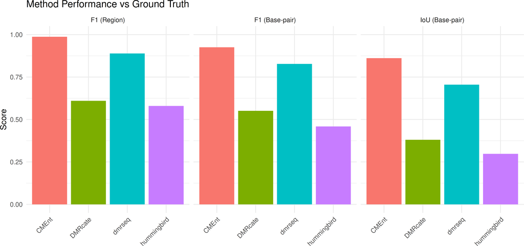

```r
plot_df <- truth_eval |>
    dplyr::select(Method, F1_regions, F1_bp, IoU_bp) |>
    tidyr::pivot_longer(
        cols = c(F1_regions, F1_bp, IoU_bp),
        names_to = "Metric",
        values_to = "Value"
    )

plot_df$Metric <- factor(
    plot_df$Metric,
    levels = c("F1_regions", "F1_bp", "IoU_bp"),
    labels = c("F1 (Region)", "F1 (Base-pair)", "IoU (Base-pair)")
)
plot_df$Method <- factor(plot_df$Method, levels = method_order)

ggplot(plot_df, aes(x = Method, y = Value, fill = Method)) +
    geom_col() +
    facet_wrap(~Metric, nrow = 1) +
    theme_minimal() +
    theme(
        axis.text.x = element_text(angle = 45, hjust = 1),
        legend.position = "none"
    ) +
    ylim(0, 1) +
    labs(
        title = "Method Performance vs Ground Truth",
        x = "",
        y = "Score"
    )
```

### 8.2 Width Distributions

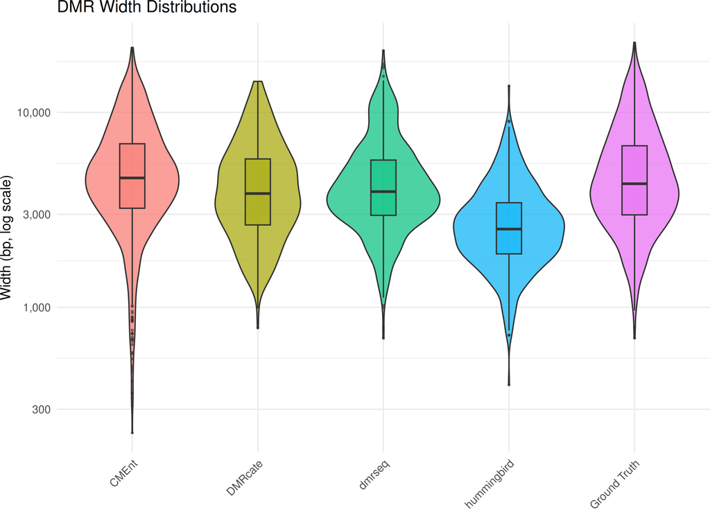

```r
width_data <- do.call(rbind, lapply(names(all_sets), function(method) {
    x <- all_sets[[method]]
    if (length(x) == 0) {
        return(NULL)
    }
    data.frame(Method = method, Width = width(x))
}))
width_data$Method <- factor(width_data$Method, levels = names(all_sets))

ggplot(width_data, aes(x = Method, y = Width, fill = Method)) +
    geom_violin(alpha = 0.7) +
    geom_boxplot(width = 0.2, alpha = 0.5, outlier.size = 0.5) +
    scale_y_log10(labels = scales::comma) +
    theme_minimal() +
    theme(
        axis.text.x = element_text(angle = 45, hjust = 1),
        legend.position = "none"
    ) +
    labs(
        title = "DMR Width Distributions",
        x = "",
        y = "Width (bp, log scale)"
    )
```

## 9 Summary

```r
cat("\n## Key Findings\n\n")
```

## 10 Key Findings

```r
if (nrow(truth_eval) > 0) {
    best_f1 <- truth_eval[which.max(truth_eval$F1_regions), ]
    best_iou <- truth_eval[which.max(truth_eval$IoU_bp), ]

    cat(sprintf(
        "- Best region-level F1: **%s** (%.3f)\n",
        best_f1$Method, best_f1$F1_regions
    ))
    cat(sprintf(
        "- Best base-pair IoU: **%s** (%.3f)\n",
        best_iou$Method, best_iou$IoU_bp
    ))

    if ("CMEnt" %in% truth_eval$Method) {
        seg <- truth_eval[truth_eval$Method == "CMEnt", ]
        cat(sprintf(
            "- **CMEnt** region metrics: Precision = %.3f, Recall = %.3f, F1 = %.3f\n",
            seg$Precision_regions, seg$Recall_regions, seg$F1_regions
        ))
        cat(sprintf(
            "- **CMEnt** base-pair metrics: Precision = %.3f, Recall = %.3f, F1 = %.3f, IoU = %.3f\n",
            seg$Precision_bp, seg$Recall_bp, seg$F1_bp, seg$IoU_bp
        ))
    }
}
```

- Best region-level F1: **CMEnt** (0.987)
- Best base-pair IoU: **CMEnt** (0.861)
- **CMEnt** region metrics: Precision = 0.981, Recall = 0.994, F1 = 0.987
- **CMEnt** base-pair metrics: Precision = 0.894, Recall = 0.959, F1 = 0.925, IoU = 0.861

[session information not shown]

R version 4.6.0 (2026-04-24) Platform: x86_64-pc-linux-gnu Running under: Ubuntu 24.04.4 LTS

Matrix products: default BLAS: /usr/lib/x86_64-linux-gnu/openblas-pthread/libblas.so.3 LAPACK: /usr/lib/x86_64-linux-gnu/openblas-pthread/libopenblasp-r0.3.26.so; LAPACK version 3.12.0

locale: [1] LC_CTYPE=C.UTF-8 LC_NUMERIC=C LC_TIME=C.UTF-8  
[4] LC_COLLATE=C.UTF-8 LC_MONETARY=C.UTF-8 LC_MESSAGES=C.UTF-8  
[7] LC_PAPER=C.UTF-8 LC_NAME=C LC_ADDRESS=C  
[10] LC_TELEPHONE=C LC_MEASUREMENT=C.UTF-8 LC_IDENTIFICATION=C

time zone: Europe/Brussels tzcode source: system (glibc)

attached base packages: [1] stats4 stats graphics grDevices datasets utils methods  
[8] base

other attached packages: [1] dplyr_1.2.1 ggplot2_4.0.3  
[3] data.table_1.18.4 bsseq_1.48.0  
[5] SummarizedExperiment_1.42.0 Biobase_2.72.0  
[7] MatrixGenerics_1.24.0 matrixStats_1.5.0  
[9] GenomicRanges_1.64.0 Seqinfo_1.2.0  
[11] IRanges_2.46.0 S4Vectors_0.50.1  
[13] BiocGenerics_0.58.1 generics_0.1.4  
[15] CMEnt_0.99.0 testthat_3.3.2  
[17] BiocStyle_2.40.0